# Regression. Basics

## Terms

Linear regression is used to predict the value of a continuous variable `Y` based on one or more input predictor variables `X`.

`X` – *independent* variables `Y` – *dependent* variable

Mathematical equation can be generalised as follows:

`Y = β1 + β2X + ϵ`

where, `β1` is the intercept and `β2` is the slope, and `ϵ` is the error term, the part of `Y` the regression model is unable to explain.

### Linear regression problems

- Non-linearity of X-Y relationship
- Outliers
- Multicollinearity
- Heteroscedasticity
- Missing values
- Need normalization

### Regression types

- Linear Regression
- Polynomial Regression
- Quantile Regression
- Ridge Regression
- Lasso Regression
- ElasticNet Regression
- Principal Component Regression
- Partial Least Square Regression
- Support Vector Regression
- Ordinal Regression
- Poisson Regression
- Negative Binomial Regression
- Quasi-Poisson Regression
- Cox Regression

## Exploratory Data Analysis

```r
# View Boston dataset
data(Boston)
Boston %>% as_tibble
```

|  | crim | zn | indus | chas | nox | rm | age | dis | rad | tax | ptratio | black | lstat | medv |
| --- | --- | --- | --- | --- | --- | --- | --- | --- | --- | --- | --- | --- | --- | --- |
| 1 | 0.00632 | 18.0 | 2.31 | 0 | 0.5380 | 6.575 | 65.2 | 4.0900 | 1 | 296 | 15.3 | 396.90 | 4.98 | 24.0 |
| 2 | 0.02731 | 0.0 | 7.07 | 0 | 0.4690 | 6.421 | 78.9 | 4.9671 | 2 | 242 | 17.8 | 396.90 | 9.14 | 21.6 |
| 3 | 0.02729 | 0.0 | 7.07 | 0 | 0.4690 | 7.185 | 61.1 | 4.9671 | 2 | 242 | 17.8 | 392.83 | 4.03 | 34.7 |
| 4 | 0.03237 | 0.0 | 2.18 | 0 | 0.4580 | 6.998 | 45.8 | 6.0622 | 3 | 222 | 18.7 | 394.63 | 2.94 | 33.4 |
| 5 | 0.06905 | 0.0 | 2.18 | 0 | 0.4580 | 7.147 | 54.2 | 6.0622 | 3 | 222 | 18.7 | 396.90 | 5.33 | 36.2 |
| 6 | 0.02985 | 0.0 | 2.18 | 0 | 0.4580 | 6.430 | 58.7 | 6.0622 | 3 | 222 | 18.7 | 394.12 | 5.21 | 28.7 |
| 7 | 0.08829 | 12.5 | 7.87 | 0 | 0.5240 | 6.012 | 66.6 | 5.5605 | 5 | 311 | 15.2 | 395.60 | 12.43 | 22.9 |
| 8 | 0.14455 | 12.5 | 7.87 | 0 | 0.5240 | 6.172 | 96.1 | 5.9505 | 5 | 311 | 15.2 | 396.90 | 19.15 | 27.1 |
| 9 | 0.21124 | 12.5 | 7.87 | 0 | 0.5240 | 5.631 | 100.0 | 6.0821 | 5 | 311 | 15.2 | 386.63 | 29.93 | 16.5 |
| 10 | 0.17004 | 12.5 | 7.87 | 0 | 0.5240 | 6.004 | 85.9 | 6.5921 | 5 | 311 | 15.2 | 386.71 | 17.10 | 18.9 |

[output cut: 496 more lines]

The dataset contains 13 different features and 1 label.

**Features:**

- CRIM - per capita crime rate by town
- ZN - proportion of residential land zoned for lots over 25000 sq.ft.
- INDUS - proportion of non-retail business acres per town
- CHAS - Charles River dummy variable (1 if tract bounds river; 0 otherwise)
- NOX - nitric oxides concentration (parts per 10 million)
- RM - average number of rooms per dwelling
- AGE - proportion of owner-occupied units built prior to 1940
- DIS - weighted distances to five Boston employment centres
- RAD - index of accessibility to radial highways
- TAX - full-value property-tax rate per $10,000
- PTRATIO - pupil-teacher ratio by town
- B - 1000(Bk - 0.63)^2 where Bk is the proportion of blacks by town
- LSTAT - % lower status of the population

**Label**

- MEDV - Median value of owner-occupied homes in $1000’s

```r
# View descriptive statistics for Boston dataset
describe(Boston) %>% as_tibble
```

|  | vars | n | mean | sd | median | trimmed | mad | min | max | range | skew | kurtosis | se |
| --- | --- | --- | --- | --- | --- | --- | --- | --- | --- | --- | --- | --- | --- |
| 1 | 1 | 506 | 3.61352356 | 8.6015451 | 0.25651 | 1.6816300 | 0.3283218 | 0.00632 | 88.9762 | 88.96988 | 5.1922223 | 36.59581589 | 0.382385321 |
| 2 | 2 | 506 | 11.36363636 | 23.3224530 | 0.00000 | 5.0800493 | 0.0000000 | 0.00000 | 100.0000 | 100.00000 | 2.2124881 | 3.95238731 | 1.036809500 |
| 3 | 3 | 506 | 11.13677866 | 6.8603529 | 9.69000 | 10.9318719 | 9.3700320 | 0.46000 | 27.7400 | 27.28000 | 0.2932747 | -1.24019490 | 0.304979888 |
| 4 | 4 | 506 | 0.06916996 | 0.2539940 | 0.00000 | 0.0000000 | 0.0000000 | 0.00000 | 1.0000 | 1.00000 | 3.3857377 | 9.48197035 | 0.011291412 |
| 5 | 5 | 506 | 0.55469506 | 0.1158777 | 0.53800 | 0.5450601 | 0.1297275 | 0.38500 | 0.8710 | 0.48600 | 0.7249897 | -0.08741064 | 0.005151391 |
| 6 | 6 | 506 | 6.28463439 | 0.7026171 | 6.20850 | 6.2528744 | 0.5122383 | 3.56100 | 8.7800 | 5.21900 | 0.4012223 | 1.84183241 | 0.031235142 |
| 7 | 7 | 506 | 68.57490119 | 28.1488614 | 77.50000 | 71.1960591 | 28.9848300 | 2.90000 | 100.0000 | 97.10000 | -0.5954162 | -0.97802966 | 1.251369525 |
| 8 | 8 | 506 | 3.79504269 | 2.1057101 | 3.20745 | 3.5393786 | 1.9142590 | 1.12960 | 12.1265 | 10.99690 | 1.0057898 | 0.45759158 | 0.093610233 |
| 9 | 9 | 506 | 9.54940711 | 8.7072594 | 5.00000 | 8.7339901 | 2.9652000 | 1.00000 | 24.0000 | 23.00000 | 0.9988651 | -0.87892910 | 0.387084894 |
| 10 | 10 | 506 | 408.23715415 | 168.5371161 | 330.00000 | 400.0443350 | 108.2298000 | 187.00000 | 711.0000 | 524.00000 | 0.6659891 | -1.15031761 | 7.492388692 |

[output cut: 4 more lines]

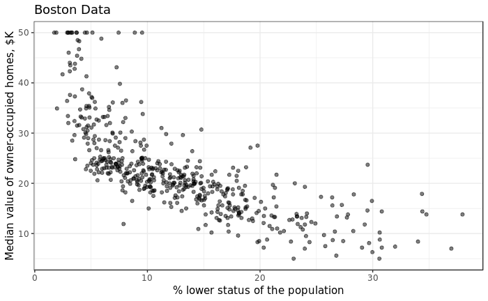

```r
# View arbitrary relation
ggplot(Boston, aes(lstat, medv)) +
  geom_point(alpha = .5) +
  labs(title = "Boston Data", x = "% lower status of the population", y = "Median value of owner-occupied homes, $K") +
  theme_bw()
```

[figure not shown]

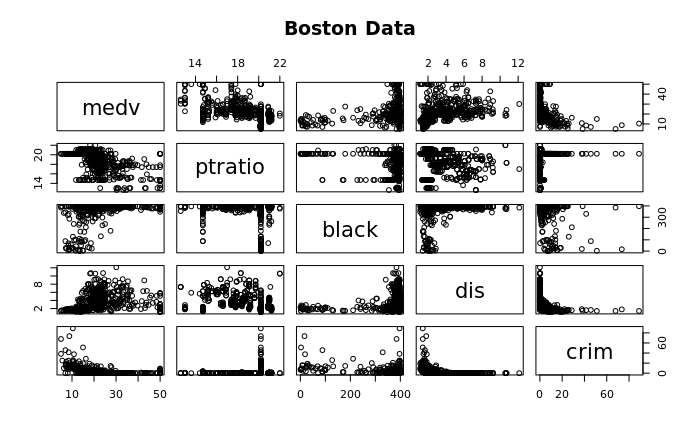

```r
# Use pairs to see more relations
pairs(~ medv + ptratio + black + dis + crim, data = Boston, main = "Boston Data")
```

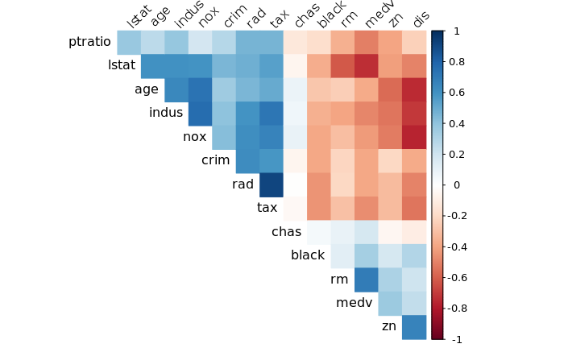

```r
# Build correlation plot
M <- Boston %>% as.matrix %>% cor
corrplot(M,
         method = "color", type = "upper", order = "hclust",
         #addCoef.col = "black", # Add coefficient of correlation
         tl.col = "black", tl.srt = 45, # Text label color and rotation
         diag = F # hide correlation coefficient on the principal diagonal
  )
```

```r
rm(M)
```

## 0. Preparation

We will split dataset on train and validation dataset for every experiment below. Let’s store our spliting index:

```r
splitter <- getSplitter(Boston, .frac = .7)
plotPrediction <- function(predict) {
  dt <- data.frame(
      Actual = df$Valid$Y,
      Predicted = predict
    ) %>%
    arrange(Predicted) %>%
    mutate(N = 1:nrow(.))

  ggplot(dt) +
    geom_point(aes(N, Actual), alpha = .5, color = "blue") +
    geom_line(aes(N, Predicted), color = "red") +
    labs(x = "Observation #", y = "Medv") +
    theme_bw()
}
```

## 1. Linear Regression

```r
# get data
df <- applySplitter(Boston, splitter)
# train model
model <- lm(medv ~ ., data = df$Train$X %>% bind_cols(medv = df$Train$Y))
summary(model)
```

```
Call:
lm(formula = medv ~ ., data = df$Train$X %>% bind_cols(medv = df$Train$Y))

Residuals:
     Min       1Q   Median       3Q      Max
-10.9472  -2.8700  -0.5564   2.3580  25.7058

Coefficients:
              Estimate Std. Error t value Pr(>|t|)
(Intercept)  37.404013   6.046018   6.187 1.77e-09 ***
crim         -0.132371   0.035047  -3.777 0.000187 ***
zn            0.052129   0.015922   3.274 0.001169 **
indus         0.021123   0.072092   0.293 0.769706
chas          2.347478   1.016045   2.310 0.021464 *
nox         -16.667334   4.932509  -3.379 0.000812 ***
rm            3.646732   0.497353   7.332 1.67e-12 ***
age           0.011131   0.015956   0.698 0.485898
dis          -1.478427   0.235750  -6.271 1.09e-09 ***
rad           0.321669   0.078361   4.105 5.07e-05 ***
tax          -0.014292   0.004421  -3.233 0.001345 **
ptratio      -0.944085   0.155693  -6.064 3.54e-09 ***
black         0.008054   0.003252   2.476 0.013759 *
lstat        -0.536622   0.058879  -9.114  < 2e-16 ***
---
Signif. codes:  0 ‘***’ 0.001 ‘**’ 0.01 ‘*’ 0.05 ‘.’ 0.1 ‘ ’ 1

Residual standard error: 4.799 on 340 degrees of freedom
Multiple R-squared:  0.7467,    Adjusted R-squared:  0.737
F-statistic: 77.09 on 13 and 340 DF,  p-value: < 2.2e-16
```

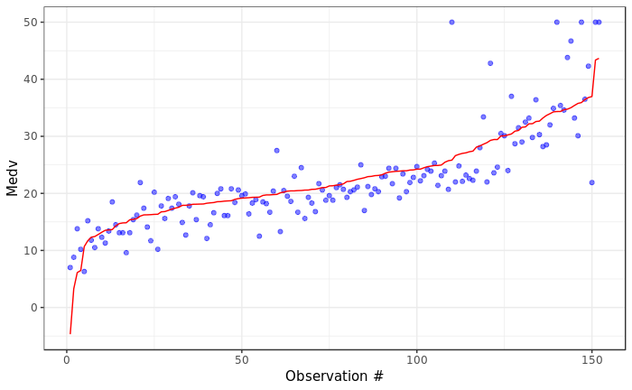

```r
# predict
predict_lm <- predict(model, newdata = df$Valid$X)
plotPrediction(predict_lm)
```

```r
# GC
rm(df); rm(model)
```

## 2. Polynomial Regression

```r
# get  data
df <- applySplitter(Boston, splitter)
df$Train$X %<>%
  mutate_if(is.double, funs("squared" = . ^ 2))
df$Valid$X %<>%
  mutate_if(is.double, funs("squared" = . ^ 2))
# train model
model <- lm(medv ~ ., data = df$Train$X %>% bind_cols(medv = df$Train$Y))
summary(model)
```

```
Call:
lm(formula = medv ~ ., data = df$Train$X %>% bind_cols(medv = df$Train$Y))

Residuals:
     Min       1Q   Median       3Q      Max
-11.9530  -2.3152  -0.2034   1.7234  25.4809

Coefficients:
                  Estimate Std. Error t value Pr(>|t|)
(Intercept)      1.670e+02  2.402e+01   6.954 1.92e-11 ***
crim            -4.421e-01  9.069e-02  -4.875 1.70e-06 ***
zn              -5.100e-02  3.638e-02  -1.402 0.161893
indus            2.618e-02  2.233e-01   0.117 0.906732
chas             2.442e+00  8.183e-01   2.984 0.003054 **
nox             -7.235e+00  3.003e+01  -0.241 0.809753
rm              -2.350e+01  3.169e+00  -7.415 1.04e-12 ***
age             -1.376e-03  4.355e-02  -0.032 0.974820
dis             -2.628e+00  6.279e-01  -4.185 3.66e-05 ***
rad              3.549e-01  1.038e-01   3.420 0.000706 ***
tax             -3.172e-02  1.472e-02  -2.155 0.031902 *
ptratio         -4.945e+00  1.913e+00  -2.585 0.010165 *
black            1.765e-02  1.248e-02   1.414 0.158174
lstat           -1.321e+00  1.501e-01  -8.802  < 2e-16 ***
crim_squared     3.755e-03  1.143e-03   3.286 0.001126 **
zn_squared       7.033e-04  3.807e-04   1.847 0.065592 .
indus_squared   -1.445e-04  8.627e-03  -0.017 0.986646
nox_squared     -1.142e+01  2.235e+01  -0.511 0.609924
rm_squared       2.102e+00  2.516e-01   8.352 1.90e-15 ***
age_squared     -3.649e-05  3.630e-04  -0.101 0.919971
dis_squared      1.402e-01  5.057e-02   2.773 0.005875 **
tax_squared      2.191e-05  1.920e-05   1.141 0.254695
ptratio_squared  1.193e-01  5.394e-02   2.211 0.027689 *
black_squared   -2.764e-05  2.800e-05  -0.987 0.324416
lstat_squared    2.352e-02  4.050e-03   5.807 1.50e-08 ***
---
Signif. codes:  0 ‘***’ 0.001 ‘**’ 0.01 ‘*’ 0.05 ‘.’ 0.1 ‘ ’ 1

Residual standard error: 3.744 on 329 degrees of freedom
Multiple R-squared:  0.8508,    Adjusted R-squared:  0.8399
F-statistic: 78.16 on 24 and 329 DF,  p-value: < 2.2e-16
```

```r
# or you use something like that
model <- lm(medv ~ lstat + crim * rm + I(lstat ^ 2) + I(rm ^ 4), data = df$Train$X %>% bind_cols(medv = df$Train$Y))
summary(model)
```

```
Call:
lm(formula = medv ~ lstat + crim * rm + I(lstat^2) + I(rm^4),
    data = df$Train$X %>% bind_cols(medv = df$Train$Y))

Residuals:
     Min       1Q   Median       3Q      Max
-12.2639  -2.6691  -0.6033   2.2546  28.3392

Coefficients:
             Estimate Std. Error t value Pr(>|t|)
(Intercept) 69.742587   7.234083   9.641  < 2e-16 ***
lstat       -1.321078   0.141736  -9.321  < 2e-16 ***
crim        -0.056078   0.249229  -0.225    0.822
rm          -8.661424   1.409041  -6.147 2.17e-09 ***
I(lstat^2)   0.021502   0.004076   5.276 2.34e-07 ***
I(rm^4)      0.011899   0.001145  10.393  < 2e-16 ***
crim:rm     -0.014844   0.040670  -0.365    0.715
---
Signif. codes:  0 ‘***’ 0.001 ‘**’ 0.01 ‘*’ 0.05 ‘.’ 0.1 ‘ ’ 1

Residual standard error: 4.335 on 347 degrees of freedom
Multiple R-squared:  0.789, Adjusted R-squared:  0.7853
F-statistic: 216.2 on 6 and 347 DF,  p-value: < 2.2e-16
```

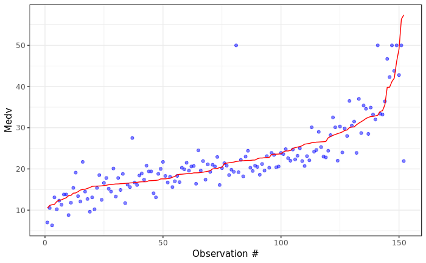

```r
# predict
predict_polylm <- predict(model, newdata = df$Valid$X) %>% as_vector
plotPrediction(predict_polylm)
```

```r
# GC
rm(df); rm(model)
```

## 3. Quantile Regression

```r
# import lib
library(quantreg)
# get  data
df <- applySplitter(Boston, splitter)
train_data <- df$Train$X %>% bind_cols(medv = df$Train$Y)
# train models
model_Q1 <- rq(medv ~ ., data = train_data, tau = .25)
summary(model_Q1)
```

```
Call: rq(formula = medv ~ ., tau = 0.25, data = train_data)

tau: [1] 0.25

Coefficients:
            coefficients lower bd  upper bd
(Intercept)  17.34021      8.55913  26.02718
crim         -0.10679     -0.41954  -0.09786
zn            0.02289      0.01080   0.04401
indus         0.02752     -0.05897   0.09436
chas          2.29041      0.68827   3.37950
nox          -7.54375    -13.31355  -2.31458
rm            4.04793      2.79648   5.89798
age          -0.03365     -0.04887  -0.01767
dis          -0.90428     -1.51942  -0.61838
rad           0.15922      0.07011   0.22930
tax          -0.01330     -0.01632  -0.00752
ptratio      -0.45715     -0.63291  -0.34912
black         0.00922      0.00388   0.01448
lstat        -0.35417     -0.46646  -0.20572
```

```r
model_median <- rq(medv ~ ., data = train_data, tau = .5)
```

```
Solution may be nonunique
```

```r
summary(model_median)
```

```
Solution may be nonunique
```

```
Call: rq(formula = medv ~ ., tau = 0.5, data = train_data)

tau: [1] 0.5

Coefficients:
            coefficients lower bd  upper bd
(Intercept)  18.77480      6.21228  28.22471
crim         -0.14741     -0.15194  -0.03753
zn            0.03355      0.01128   0.05918
indus        -0.00233     -0.04922   0.02863
chas          2.06002      0.56005   2.87998
nox         -11.39142    -16.50716  -3.43991
rm            5.13114      3.85413   6.27466
age          -0.02572     -0.04921  -0.00114
dis          -1.01974     -1.28817  -0.68980
rad           0.23675      0.14723   0.31568
tax          -0.01266     -0.01680  -0.00879
ptratio      -0.79417     -0.91342  -0.53147
black         0.01018      0.00692   0.01576
lstat        -0.26505     -0.40573  -0.18667
```

```r
model <- rq(medv ~ ., data = train_data, tau = c(.05, .25, .5, .75, .95))
```

```
Solution may be nonunique
```

```r
summary(model)
```

```
Solution may be nonunique
```

```
Call: rq(formula = medv ~ ., tau = c(0.05, 0.25, 0.5, 0.75, 0.95),
    data = train_data)

tau: [1] 0.05

Coefficients:
            coefficients   lower bd       upper bd
(Intercept)   1.993864e+01  -1.027363e+01   4.957434e+01
crim         -2.345100e-01  -3.366320e+00  -3.651000e-02
zn            1.520000e-03  -3.693000e-02   5.130000e-02
indus         5.550000e-02  -7.981000e-02   2.906000e-01
chas          3.942510e+00 -1.797693e+308   4.982520e+00
nox          -1.271381e+01  -3.541526e+01  -2.984100e-01
rm            3.238300e+00   1.465130e+00   5.756290e+00
age          -4.169000e-02  -7.134000e-02  -5.940000e-03
dis          -6.965100e-01  -1.777320e+00   1.512700e-01
rad           1.788600e-01   5.140000e-03   4.655000e-01
tax          -1.142000e-02  -2.431000e-02  -7.500000e-03
ptratio      -4.019800e-01  -1.043880e+00   2.846100e-01
black         1.047000e-02  -2.140000e-03   1.546000e-02
lstat        -3.089900e-01  -5.635300e-01  -8.252000e-02

Call: rq(formula = medv ~ ., tau = c(0.05, 0.25, 0.5, 0.75, 0.95),
    data = train_data)

tau: [1] 0.25

Coefficients:
            coefficients lower bd  upper bd
(Intercept)  17.34021      8.55913  26.02718
crim         -0.10679     -0.41954  -0.09786
zn            0.02289      0.01080   0.04401
indus         0.02752     -0.05897   0.09436
chas          2.29041      0.68827   3.37950
nox          -7.54375    -13.31355  -2.31458
rm            4.04793      2.79648   5.89798
age          -0.03365     -0.04887  -0.01767
dis          -0.90428     -1.51942  -0.61838
rad           0.15922      0.07011   0.22930
tax          -0.01330     -0.01632  -0.00752
```

[output cut: 54 more lines]

```
            coefficients   lower bd       upper bd
(Intercept)   2.997106e+01   1.623078e+01   9.964660e+01
crim         -3.751000e-01  -3.851200e-01   7.730100e+00
zn            9.146000e-02  -1.355000e-02   1.018300e-01
indus         1.459000e-01  -3.351400e-01   6.875000e-01
chas          9.745300e-01  -5.043500e-01  1.797693e+308
nox          -2.294947e+01  -5.073640e+01   1.576907e+01
rm            5.589650e+00   2.217480e+00   6.612810e+00
age           3.914000e-02  -6.308000e-02   1.499700e-01
dis          -1.993900e+00  -2.053230e+00  -6.049900e-01
rad           6.776700e-01   2.081600e-01   1.312720e+00
tax          -3.980000e-03  -4.573000e-02   2.049000e-02
ptratio      -9.065900e-01  -2.564960e+00  -4.340900e-01
black         2.710000e-03  -1.984600e-01   4.590000e-02
lstat        -4.661400e-01  -7.000600e-01  -3.826500e-01
```

```r
# predict
predict_quantreg <- predict(model, newdata = df$Valid$X)
predict_quantreg %>% as_tibble
```

| tau= 0.05 | tau= 0.25 | tau= 0.50 | tau= 0.75 | tau= 0.95 |
| --- | --- | --- | --- | --- |
| 22.240877 | 25.602082 | 28.193345 | 33.058161 | 35.138690 |
| 24.465159 | 26.818669 | 28.383071 | 31.169355 | 32.484259 |
| 18.062788 | 19.902720 | 22.567653 | 25.645451 | 28.978694 |
| 14.958539 | 16.543388 | 19.637857 | 22.703620 | 25.400833 |
| 17.823256 | 19.223377 | 21.836187 | 23.326726 | 25.884640 |
| 17.181460 | 18.869753 | 18.904623 | 20.538626 | 24.538554 |
| 16.085596 | 18.058232 | 18.622289 | 21.055137 | 25.757285 |
| 15.039967 | 16.317947 | 15.919159 | 15.966601 | 20.656749 |
| 14.756252 | 16.604414 | 17.437246 | 19.696063 | 24.394950 |
| 11.875709 | 13.411964 | 14.691777 | 16.580174 | 20.936888 |

[output cut: 142 more lines]

```r
# get prediction with minimal MAE
MAEs <- predict_quantreg %>%
  as.data.frame %>%
  mutate(Actual = df$Valid$Y) %>%
  mutate_all(funs(abs(. - Actual))) %>%
  select(-Actual) %>%
  colSums(.)/length(df$Valid$Y)
print(MAEs)
```

```
tau= 0.05 tau= 0.25 tau= 0.50 tau= 0.75 tau= 0.95
 5.130508  3.348160  3.001112  4.105269 10.252167
```

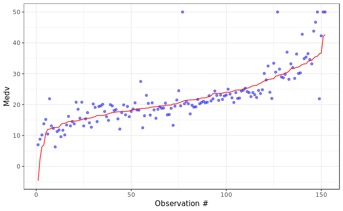

```r
predict_quantreg <- predict_quantreg[, which.min(MAEs)]
plotPrediction(predict_quantreg)
```

```r
# GC
rm(df); rm(train_data); rm(MAEs)
rm(model_Q1); rm(model_median); rm(model)
```

## 4. Lasso Regression

*Least Absolute Shrinkage and Selection Operator, LASSO* makes use of *L1 regularization*.

#### Regularization

Regularization adding a penalty term to the objective function and control the model complexity using that penalty term.

Regularization is generally useful in the following situations:

- Large number of variables;
- Low ratio of number observations to number of variables;
- High Multi-Collinearity.

In **L1 regularization** we try to minimize the objective function by adding a penalty term to the sum of the absolute values of coefficients.

In **L2 regularization** we try to minimize the objective function by adding a penalty term to the sum of the squares of coefficients.

```r
# import lib
library(glmnet)
# get  data
df <- applySplitter(Boston, splitter)
# train model
model <- cv.glmnet(df$Train$X %>% as.matrix,
                   df$Train$Y,
                   alpha = 1, lambda = 10 ^ seq(1, -1, by = -.1))
model$lambda.min
```

```
[1] 0.1
```

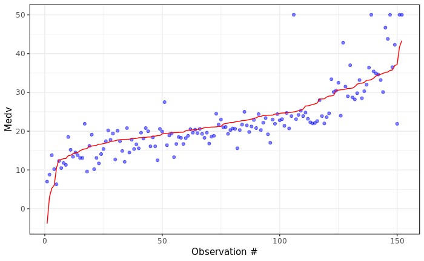

```r
# predict
predict_lasso <- predict(model,
                         newx = df$Valid$X %>% as.matrix,
                         s = model$lambda.min,
                         type = "response")[, 1] %>% as_vector
plotPrediction(predict_lasso)
```

```r
# GC
rm(df); rm(model)
```

## 5. Ridge Regression

Ridge Regression makes use of *L2 regularization*.

```r
# import lib
library(glmnet)
# get  data
df <- applySplitter(Boston, splitter)
# train model
model <- cv.glmnet(df$Train$X %>% as.matrix,
                   df$Train$Y,
                   alpha = 0, lambda = 10 ^ seq(1, -1, by = -.1))
model$lambda.min
```

```
[1] 0.1258925
```

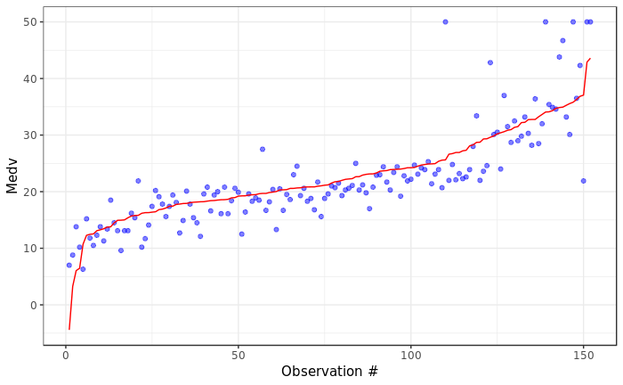

```r
# predict
predict_ridge <- predict(model,
                         newx = df$Valid$X %>% as.matrix,
                         s = model$lambda.min,
                         type = "response")[, 1] %>% as_vector
plotPrediction(predict_ridge)
```

```r
# GC
rm(df); rm(model)
```

## 6. Elastic Net Regression

Elastic Net Regression is a combination of both *L1 and L2 regularization*. It is dealing with highly correlated independent variables.

```r
# import lib
library(glmnet)
# get  data
df <- applySplitter(Boston, splitter)
# train model
model <- cv.glmnet(df$Train$X %>% as.matrix,
                   df$Train$Y,
                   alpha = .5, lambda = 10 ^ seq(1, -1, by = -.1))
model$lambda.min
```

```
[1] 0.1
```

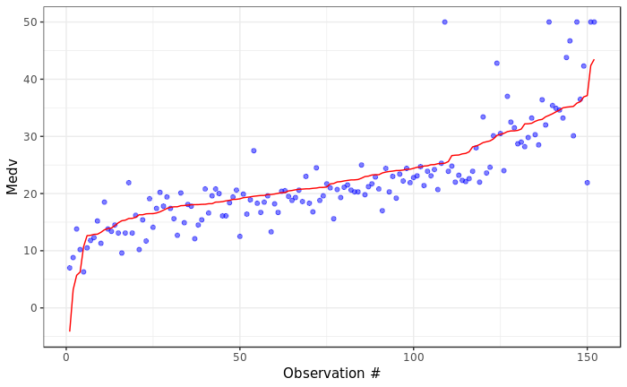

```r
# predict
predict_enr <- predict(model,
                         newx = df$Valid$X %>% as.matrix,
                         s = model$lambda.min,
                         type = "response")[, 1] %>% as_vector
plotPrediction(predict_enr)
```

```r
# GC
rm(df); rm(model)
```

## Gradient Boosted Trees for Regression

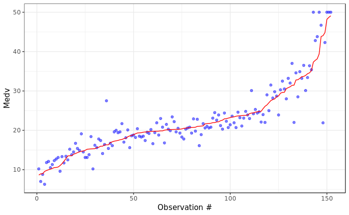

```r
# import lib
library(lightgbm)
# get  data
df <- applySplitter(Boston, splitter)
dTrain <- lgb.Dataset(df$Train$X %>% as.matrix, label = df$Train$Y)
dValid <- lgb.Dataset(df$Valid$X %>% as.matrix, label = df$Valid$Y)
# train model
params <- list(learning_rate = .01,
               min_data = 1,
               boosting_type = "gbdt",
               objective = "regression",
               metric = "mae")
n_rounds <- 1e3L
model <- lgb.train(params,
                   dTrain,
                   valids = list(Valid = dValid),
                   nrounds = n_rounds,
                   early_stopping_rounds = n_rounds/10,
                   verbose = 0)
# predict
predict_gbt <- predict(model, data = df$Valid$X %>% as.matrix)
plotPrediction(predict_gbt)
```

```r
# GC
rm(df); rm(dTrain); rm(dValid)
rm(model); rm(params); rm(n_rounds)
```

## Neural Networks for Regression

```r
# import lib
library(keras)
# get data
df <- applySplitter(Boston, splitter)
## Normalize features
# NOTE: validation dataset *cannot* used when calculating mean and SD
# normalize train dataset
df$Train$X <- scale(df$Train$X, center = T, scale = T)
df$Train$X %>% as_tibble
```

| crim | zn | indus | chas | nox | rm | age | dis | rad | tax | ptratio | black | lstat |
| --- | --- | --- | --- | --- | --- | --- | --- | --- | --- | --- | --- | --- |
| -0.366661070 | -0.49631136 | -0.07518002 | 3.5467940 | -0.550243130 | -1.2380618660 | 0.703933342 | -0.087101491 | -0.6330986 | -0.77773116 | 0.06267409 | 0.409925616 | 1.546521490 |
| -0.401584506 | 2.75653236 | -1.32427251 | -0.2811483 | -1.241693322 | -0.8746274008 | -1.674864072 | 3.107361497 | -0.6330986 | -0.44017342 | 1.64080235 | 0.275207850 | -0.636091265 |
| -0.392289291 | -0.49631136 | -0.15864473 | -0.2811483 | -0.022557457 | -0.1547745798 | 0.129740863 | -0.518633481 | -0.4034706 | 0.14018901 | -0.30865021 | 0.388916575 | -0.089410481 |
| 0.439338065 | -0.49631136 | 1.00554401 | -0.2811483 | 0.314069610 | -1.2057877629 | 0.946449420 | -0.657246228 | 1.6631812 | 1.52595236 | 0.80532268 | -0.052056693 | 0.746367159 |
| -0.395442968 | -0.49631136 | 0.24716642 | -0.2811483 | -1.023340630 | -0.0102427269 | 0.201069121 | 0.091622637 | -0.5182846 | -0.06116122 | 0.10908962 | 0.176227111 | -0.099001372 |
| -0.398738325 | -0.49631136 | 0.39970537 | -0.2811483 | 0.004736629 | 0.4991268131 | 0.579108890 | -0.199681074 | -0.5182846 | -0.78365322 | -0.95846773 | 0.383285286 | -0.411390392 |
| -0.398728880 | -0.49631136 | -1.01631653 | -0.2811483 | -0.359184525 | -0.3736771921 | -0.772561604 | -0.137921549 | -0.5182846 | -0.66521191 | -0.86563666 | 0.388158517 | -0.353845046 |
| -0.404722441 | 3.16313783 | -1.42356673 | -0.2811483 | -1.332673611 | 1.3508824901 | -1.674864072 | 2.235389004 | -0.5182846 | -1.07975650 | -0.26223467 | 0.417397904 | -1.080012504 |
| -0.399668161 | 1.13011050 | -0.67670152 | 3.5467940 | -0.932360342 | 0.7573196378 | -1.471578535 | 0.465780120 | -0.6330986 | -0.91393867 | -0.40148128 | 0.390540986 | -1.169070777 |
| -0.394208784 | 0.72350504 | -0.88968042 | -0.2811483 | -1.105222890 | 0.8569483908 | -0.519346287 | 1.145827272 | -0.4034706 | -0.64152365 | -0.86563666 | 0.366716300 | -0.179838881 |

[output cut: 344 more lines]

```r
# use means and SDs from training set to normalize validation dataset
means_train <- attr(df$Train$X, "scaled:center")
sd_train <- attr(df$Train$X, "scaled:scale")
df$Valid$X <- scale(df$Valid$X, center = means_train, scale = sd_train)
df$Valid$X %>% as_tibble
```

| crim | zn | indus | chas | nox | rm | age | dis | rad | tax | ptratio | black | lstat |
| --- | --- | --- | --- | --- | --- | --- | --- | --- | --- | --- | --- | --- |
| -0.405435036 | 0.23557848 | -1.26671065 | -0.2811483 | -0.10443972 | 0.40511095 | -0.13060728 | 0.10907039 | -0.9775406 | -0.66521191 | -1.46903864 | 0.42790242 | -1.056720340 |
| -0.402701149 | -0.49631136 | -1.28541825 | -0.2811483 | -0.83228202 | 0.99867380 | -0.82249139 | 1.01940026 | -0.7479126 | -1.10344477 | 0.10908962 | 0.40331968 | -1.336226305 |
| -0.396832475 | 0.01194547 | -0.46660071 | -0.2811483 | -0.23181212 | -0.38490297 | -0.08067750 | 0.78782512 | -0.5182846 | -0.57638093 | -1.51545418 | 0.41382420 | -0.035975517 |
| -0.388253003 | 0.01194547 | -0.46660071 | -0.2811483 | -0.23181212 | -0.39612874 | 0.60764019 | 1.26399198 | -0.5182846 | -0.57638093 | -1.51545418 | 0.31755081 | 0.603873922 |
| -0.396256313 | 0.01194547 | -0.46660071 | -0.2811483 | -0.23181212 | -0.55749926 | -1.06500746 | 0.73723585 | -0.5182846 | -0.57638093 | -1.51545418 | 0.35859425 | 0.413426230 |
| -0.340006462 | -0.49631136 | -0.42774645 | -0.2811483 | -0.10443972 | -0.47330595 | -0.25186532 | 0.39409661 | -0.6330986 | -0.60006919 | 1.17664698 | 0.42790242 | -0.607318592 |
| -0.339145891 | -0.49631136 | -0.42774645 | -0.2811483 | -0.10443972 | -0.26703233 | 0.55771041 | 0.28073233 | -0.6330986 | -0.60006919 | 1.17664698 | 0.24510211 | -0.333293137 |
| -0.321855763 | -0.49631136 | -0.42774645 | -0.2811483 | -0.10443972 | -1.16509433 | -1.15060137 | -0.02640360 | -0.6330986 | -0.60006919 | 1.17664698 | -0.74069840 | -0.137364936 |
| -0.316678694 | -0.49631136 | -0.42774645 | -0.2811483 | -0.10443972 | -0.45085440 | 0.72533182 | 0.07320556 | -0.6330986 | -0.60006919 | 1.17664698 | 0.38057794 | 0.155842302 |
| -0.302364882 | -0.49631136 | -0.42774645 | -0.2811483 | -0.10443972 | -0.66414412 | 1.11050441 | 0.11147062 | -0.6330986 | -0.60006919 | 1.17664698 | 0.40234503 | 0.984769306 |

[output cut: 142 more lines]

```r
# build deep FFNN model
model <- keras_model_sequential() %>%
  layer_dense(
    input_shape = dim(df$Train$X)[2],
    units = 64,
    activation = "relu"
  ) %>%
  layer_dense(
    units = 64,
    activation = "relu"
  ) %>%
  layer_dense(
    units = 64,
    activation = "relu"
  ) %>%
  layer_dense(units = 1)
model %>% compile(
  loss = "mse",
  optimizer = optimizer_rmsprop(),
  metrics = list("mean_absolute_error")
)
summary(model)
```

```
______________________________________________________________________________________________________________________________________________________________________________
Layer (type)                                                                  Output Shape                                                         Param #
==============================================================================================================================================================================
dense_17 (Dense)                                                              (None, 64)                                                           896
______________________________________________________________________________________________________________________________________________________________________________
dense_18 (Dense)                                                              (None, 64)                                                           4160
______________________________________________________________________________________________________________________________________________________________________________
dense_19 (Dense)                                                              (None, 64)                                                           4160
______________________________________________________________________________________________________________________________________________________________________________
dense_20 (Dense)                                                              (None, 1)                                                            65
==============================================================================================================================================================================
Total params: 9,281
Trainable params: 9,281
Non-trainable params: 0
______________________________________________________________________________________________________________________________________________________________________________
```

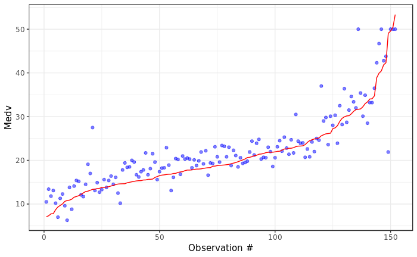

```r
n_epochs <- 100L
history <- model %>% fit(
  df$Train$X, df$Train$Y,
  epochs = n_epochs,
  batch_size = 32L,
  validation_data = list(df$Valid$X, df$Valid$Y),
  callbacks = callback_early_stopping(monitor = "val_loss", patience = 20L),
  verbose = 0
)
# Look what's going on (print in terminal):
#! htop
#! watch -n 0.5 nvidia-smi
# predict
predict_nn <- model %>% predict(df$Valid$X)
predict_nn <- predict_nn[, 1]
plotPrediction(predict_nn)
```

```r
# GC
rm(df); rm(means_train); rm(sd_train)
rm(model); rm(history); rm(n_epochs)
```

## Compare models

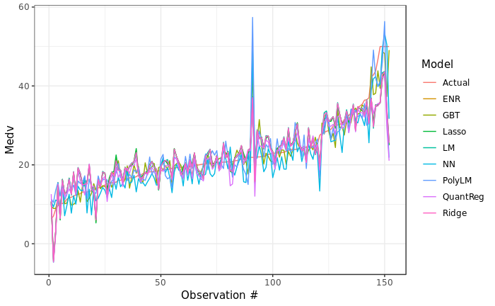

```r
df <- applySplitter(Boston, splitter)
data.plot <- data_frame(
    Actual = df$Valid$Y,
    LM = predict_lm,
    PolyLM = predict_polylm,
    Lasso = predict_lasso,
    Ridge = predict_ridge,
    QuantReg = predict_quantreg,
    ENR = predict_enr,
    GBT = predict_gbt,
    NN = predict_nn
  ) %>%
  arrange(Actual) %>%
  mutate(N = 1:nrow(.)) %>%
  gather("Model", "Value", -N)
ggplot(data.plot, aes(x = N, y = Value, color = Model)) +
  geom_line() +
  labs(x = "Observation #", y = "Medv") +
  theme_bw()
```

## References

1. https://www.listendata.com/2018/03/regression-analysis.html
2. https://www.machinelearningplus.com/machine-learning/complete-introduction-linear-regression-r/